# Data Analysis Tools final project

Alejandro García, Biel Cantera, Laura Martín and Lia Siroo

2023-01-23

# PREPARING ALL THE DATA

In order to start we download the .csv files from https://opendata-ajuntament.barcelona.cat/data/en/dataset/contaminants-estacions-mesura-qualitat-aire. When importing the files to RStudio, we have to set the working directory to where the files are located.

```r
library(tidyverse)
library(ggplot2)

setwd("~/DATA ANALYSIS/AIR QUALITY/FINAL PROJETC")

jan <- read.csv("2022_01_Gener_qualitat_aire_BCN.csv")
feb <- read.csv("2022_02_Febrer_qualitat_aire_BCN.csv")
mar <- read.csv("2022_03_Marc_qualitat_aire_BCN.csv")
apr <- read.csv("2022_04_Abril_qualitat_aire_BCN.csv")
may <- read.csv("2022_05_Maig_qualitat_aire_BCN.csv")
jun <- read.csv("2022_06_Juny_qualitat_aire_BCN.csv")
jul <- read.csv("2022_07_Juliol_qualitat_aire_BCN.csv")
aug <- read.csv("2022_08_Agost_qualitat_aire_BCN.csv")
sep <- read.csv("2022_09_Setembre_qualitat_aire_BCN.csv")
oct <- read.csv("2022_10_Octubre_qualitat_aire_BCN.csv")
nov <- read.csv("2022_11_Novembre_qualitat_aire_BCN.csv")
dec <- read.csv("2022_12_Desembre_qualitat_aire_BCN.csv")
cont <- read.csv("qualitat_aire_contaminants.csv")
est <- read.csv("2022_qualitat_aire_estacions (1).csv")
trees <- read.csv("OD_Arbrat_Parcs_BCN.csv")
st_trees <- read.csv("OD_Arbrat_Viari_BCN.csv")
```

We merge all the datasets together to have a common 2022 dataset. We use the union function as we want all the observations in the dataset, one after the other.

```r
jan_feb <- union(jan,feb)

m3 <-union(jan_feb,mar)

m4 <- union(m3,apr)

m5 <- union(m4,may)

m6 <- union(m5,jun)

m7 <- union(m6,jul)

m8 <- union(m7,aug)

m9 <- union(m8,sep)

m10 <- union(m9,oct)

m11 <- union(m10,nov)

air2022 <- union(m11,dec)

alltrees <- union(trees, st_trees)
```

We delete the datasets created before, keeping the air2022 and alltrees datasets.

```r
rm(jan,feb,jan_feb,mar,apr,may,jun,jul,aug,sep,oct,nov,dec,m3,m4,m5,m6,m7,m8,m9,m10,m11)
rm(trees, st_trees)
```

We delete all NA values.

```r
cair <- na.omit(air2022)
```

We convert the H variables and their values into observations so we can analyze and plot the information easier.

```r
pivair <- cair %>%
  pivot_longer(
    cols = starts_with("H"),
    names_to = "Hours",
    names_prefix = "H",
    values_to = "Pollution_lvl",
    values_drop_na = TRUE
  )
pivair2 <- pivair[,-c(10:33)]
pivair <- pivair2
rm(pivair2)
```

We create a function so when R reads the number of the district, it will tell the name of the district. Then, we mutate the dataset for the variable districte to follow the delimitated function (using names of district instead of numbers).

```r
est_f <- function(x){
  cut(
    x,
    breaks = c(-Inf, 4, 42, 43, 44, 50, 54, 57, 58, Inf),
    labels = c("San Marti", "Sants-Montjuic", "Eixample", "Gracia", "Ciutat Vella", "Horta-Guinardo", "Les Corts", "Sarria-Sant Gervasi", "NA")
  )
}
air2 <- mutate(pivair, DISTRICTE = est_f(ESTACIO))
```

We now count the number of trees per district.

```r
gtrees <- group_by(alltrees, nom_districte)
strees <- summarise(gtrees, Arboles = n())
```

Subsequently, we correct the mistakes on the names of the districts, so instead of saying GRÃ€CIA, it is well written and in the same manner as the other dataset, Gracia.

```r
strees2 <- strees
strees2$nom_districte <- gsub("GRÃ€CIA", "Gracia", strees2$nom_districte)
strees2$nom_districte <- gsub("HORTA - GUINARDÃ“", "Horta-Guinardo", strees2$nom_districte)
strees2$nom_districte <- gsub("CIUTAT VELLA", "Ciutat Vella", strees2$nom_districte)
strees2$nom_districte <- gsub("EIXAMPLE", "Eixample", strees2$nom_districte)
strees2$nom_districte <- gsub("LES CORTS", "Les Corts", strees2$nom_districte)
strees2$nom_districte <- gsub("NOU BARRIS", "Nou Barris", strees2$nom_districte)
strees2$nom_districte <- gsub("SANT ANDREU", "Sant Andreu", strees2$nom_districte)
strees2$nom_districte <- gsub("SANT MARTÃ", "San Marti", strees2$nom_districte)
strees2$nom_districte <- gsub("SANTS - MONTJUÃC", "Sants-Montjuic", strees2$nom_districte)
strees2$nom_districte <- gsub("SARRIÃ€ - SANT GERVASI", "Sarria-San Gervasi", strees2$nom_districte)
strees <- strees2
names(strees) <- c("DISTRICTE", "ARBRES")
```

# ANALYZING THE DATA

## Analyzing trees in each district

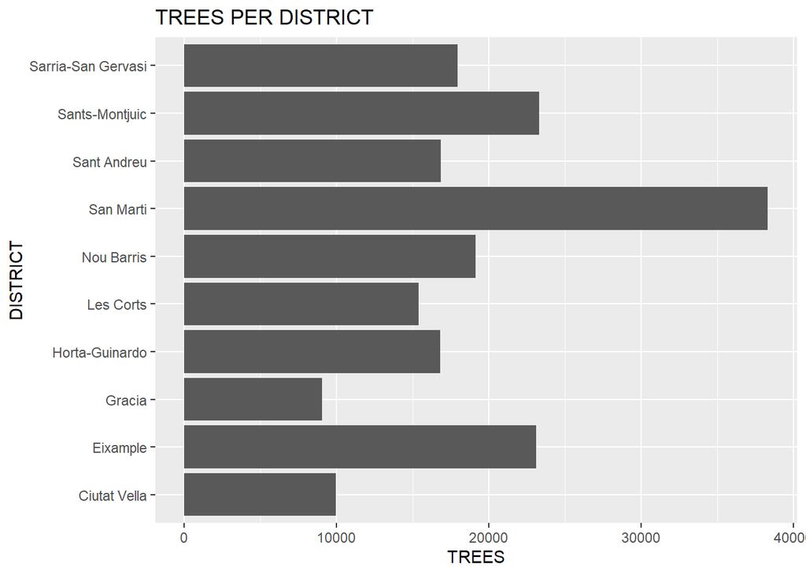

```r
ggplot(strees) +
  geom_col(mapping = aes(x = DISTRICTE, y = ARBRES))+
  coord_flip()+
  labs(title = "TREES PER DISTRICT")+
  xlab("DISTRICT")+
  ylab("TREES")
```

In this graph we can see the number of trees in each district. The neighborhood of Sant Marti is the one that has the highest number of trees with almost 40000, and Gràcia the one with less, with an approximate amount of 10000

## Analayzing the presence of each contaminant per district

Following, we analize how the level of each contaminant in each district and we delete the contaminants that aren’t useful.

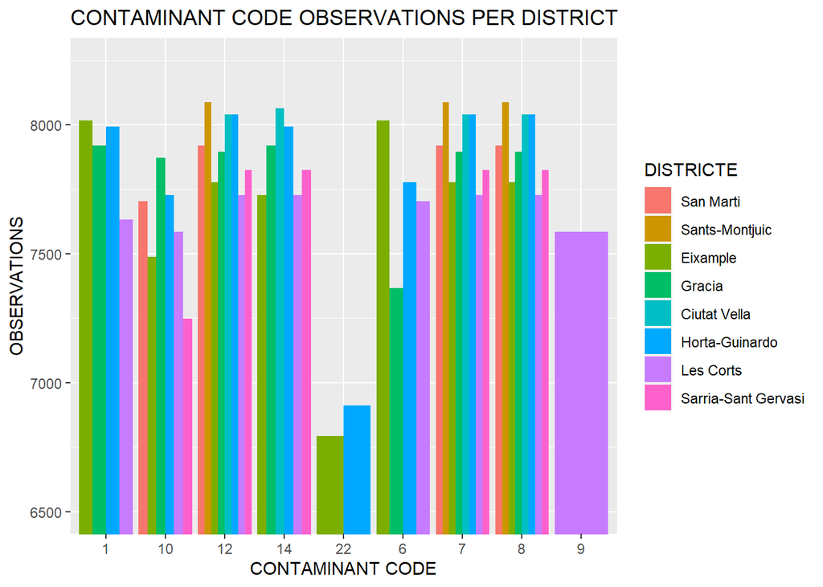

```r
gcont2 <- group_by(air2, CODI_CONTAMINANT, DISTRICTE)
scont2 <- summarise(gcont2, count = n())
scont3 <- filter(scont2, CODI_CONTAMINANT != 901, CODI_CONTAMINANT != 996, CODI_CONTAMINANT != 997,
                 CODI_CONTAMINANT != 998, CODI_CONTAMINANT != 999, CODI_CONTAMINANT != 106, CODI_CONTAMINANT != 107,
                 CODI_CONTAMINANT != 108, CODI_CONTAMINANT != 109, CODI_CONTAMINANT != 110, CODI_CONTAMINANT != 112,
                 CODI_CONTAMINANT != 114, CODI_CONTAMINANT != 101)
ggplot(scont3)+
  geom_col(mapping = aes(x = as.character(CODI_CONTAMINANT), y = count, fill = DISTRICTE), position = "dodge")+
  coord_cartesian(ylim = c(6500,8250))+
  labs(title = "CONTAMINANT CODE OBSERVATIONS PER DISTRICT")+
  xlab("CONTAMINANT CODE")+
  ylab("OBSERVATIONS")
```

In this graph we can see the relationship between the repetition of times the contaminants have been given a value and each contaminant for each neighborhood. We can easily see that not all neighborhoods have contaminants. There is no neighborhood that stands out because of their high level of pollution

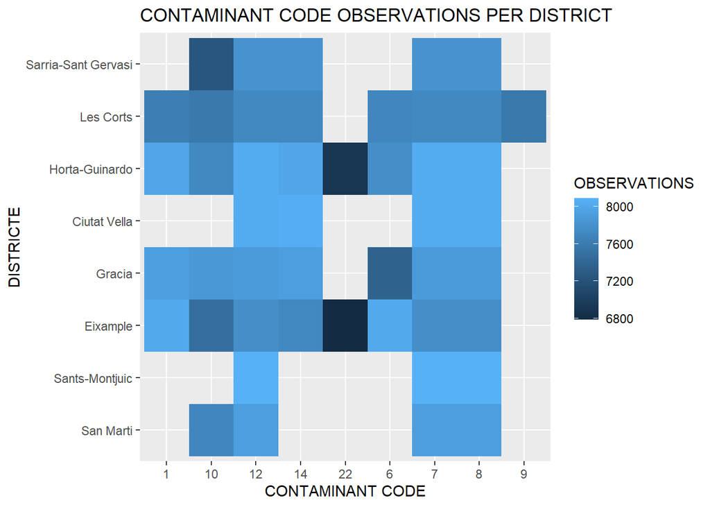

```r
ggplot(scont3)+
  geom_tile(mapping = aes(x = as.character(CODI_CONTAMINANT), y = DISTRICTE, fill = count))+
  labs(title = "CONTAMINANT CODE OBSERVATIONS PER DISTRICT", fill = "OBSERVATIONS")+
  xlab("CONTAMINANT CODE")
```

## Analyzing each contaminant separately by district

### SO2

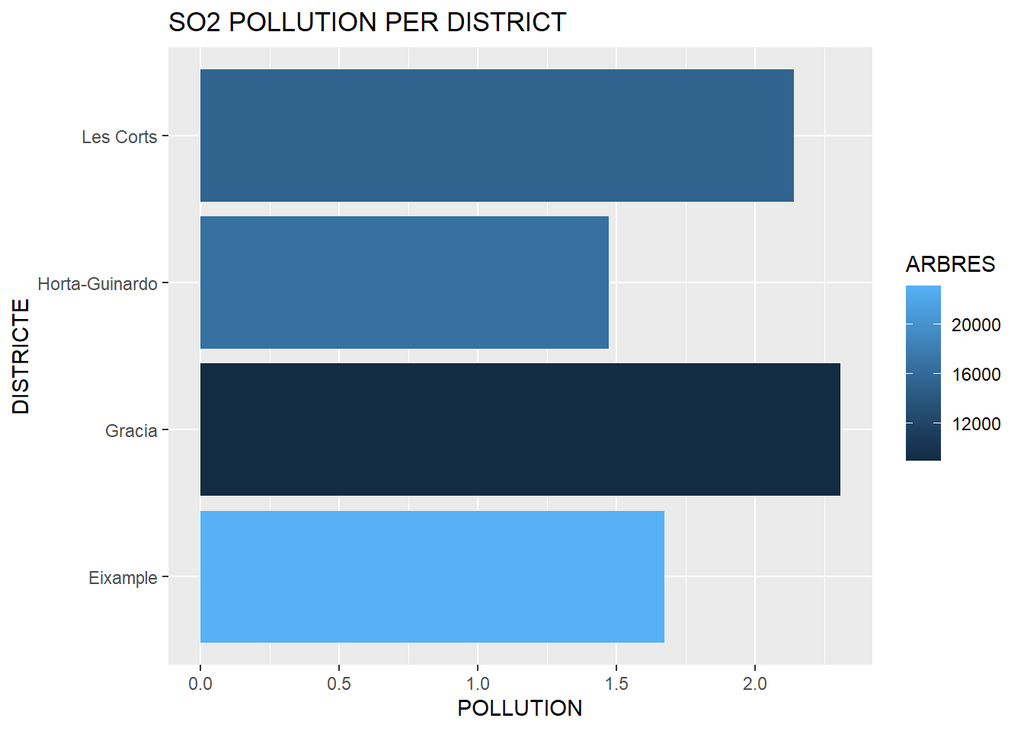

```r
SO2 <- filter(air2, CODI_CONTAMINANT == 1)
gSO2 <- group_by(SO2, DISTRICTE)
sSO2 <- summarise(gSO2, Polucion = mean(Pollution_lvl))
SO2tree <- left_join(sSO2, strees, by = "DISTRICTE")
ggplot(SO2tree)+
  geom_col(mapping = aes(x = Polucion, y = DISTRICTE, fill = ARBRES))+
  labs(title = "SO2 POLLUTION PER DISTRICT")+
  xlab("POLLUTION")
```

In this graph we can see the relationship between the districts that have the contaminant SO2 and the pollution levels of this one, taking into consideration the number of trees in each area. There is an existence of a relationship between the number of trees and the SO2 pollution levels, meaning that if there are more trees in the neighborhood there is less pollution. Take for example the district of Gràcia, which doesn’t have many trees and therefore the pollution levels of this contaminant are high. In contrast, in Eixample, the opposite thing happens, lots of trees and less pollution.

### NO

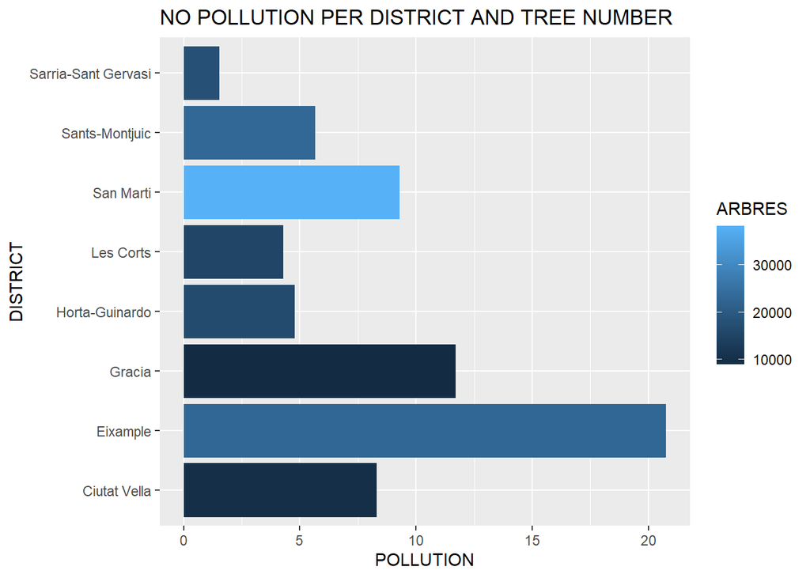

```r
NO <- filter(air2, CODI_CONTAMINANT == 7)
gNO <- group_by(NO, DISTRICTE)
sNO <- summarise(gNO, Polucion = mean(Pollution_lvl))
sNOtree <- left_join(sNO, strees, by = "DISTRICTE")
sNOtree[8,3] <- 17951
ggplot(sNOtree)+
  geom_col(mapping = aes(x = Polucion, y = DISTRICTE, fill = ARBRES))+
  labs(title = "NO POLLUTION PER DISTRICT AND TREE NUMBER")+
  xlab("POLLUTION")+
  ylab("DISTRICT")
```

In this graph we can see the relationship between the districts that have the contaminant NO and the pollution levels of this one, taking into consideration the number of trees in each area. There is no clear relationship between the number of trees and the pollution levels of each area.

### NO2

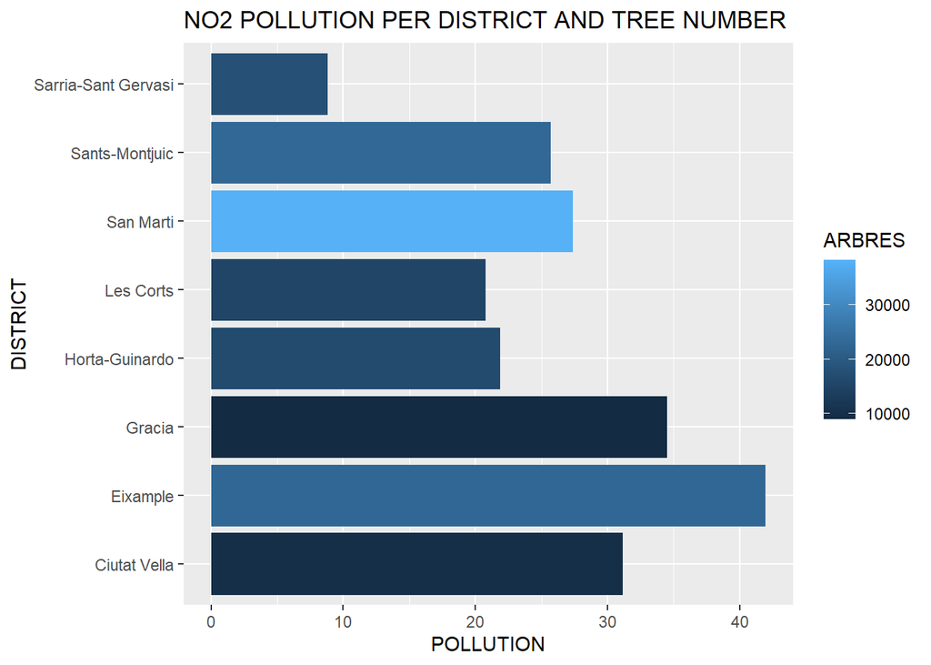

```r
NO2 <- filter(air2, CODI_CONTAMINANT == 8)
gNO2 <- group_by(NO2, DISTRICTE)
sNO2 <- summarise(gNO2, Polucion = mean(Pollution_lvl))
sNO2tree <- left_join(sNO2, strees, by = "DISTRICTE")
sNO2tree[8,3] <- 17951
ggplot(sNO2tree)+
  geom_col(mapping = aes(x = Polucion, y = DISTRICTE, fill = ARBRES))+
  labs(title = "NO2 POLLUTION PER DISTRICT AND TREE NUMBER")+
  xlab("POLLUTION")+
  ylab("DISTRICT")
```

In this graph we can see the relationship between the districts that have the contaminant NO2 and the pollution levels of this one, taking into consideration the number of trees in each area. There is no clear relationship between the number of trees and the pollution levels of each area.

### PM2.5

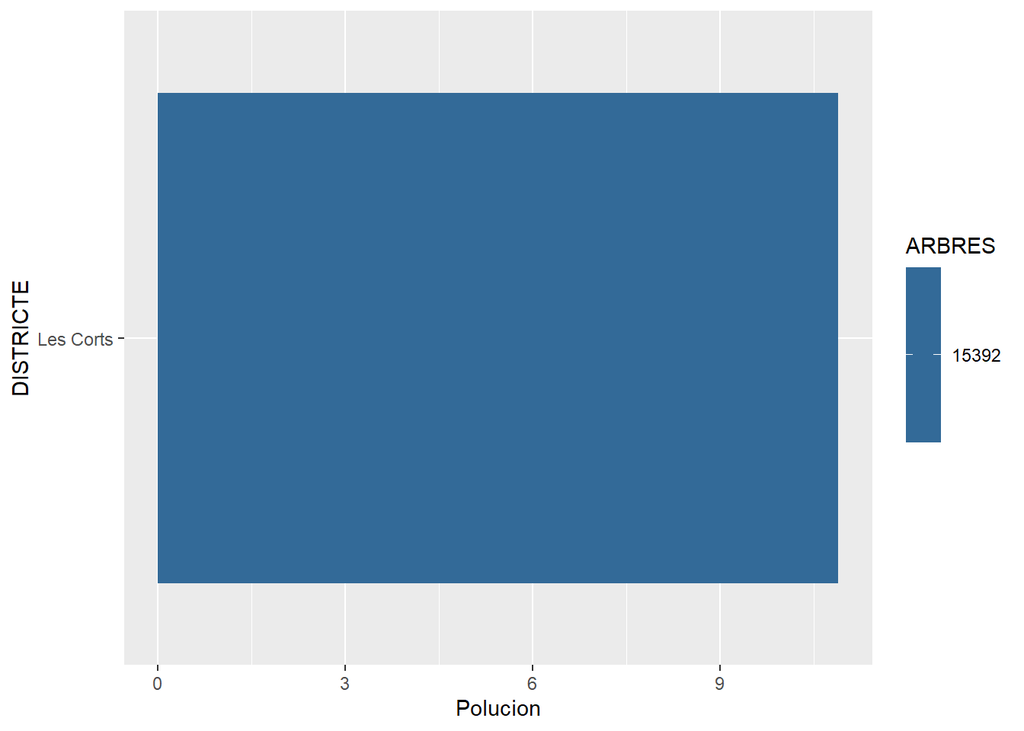

```r
PM2.5 <- filter(air2, CODI_CONTAMINANT == 9)
gPM2.5 <- group_by(PM2.5, DISTRICTE)
sPM2.5 <- summarise(gPM2.5, Polucion = mean(Pollution_lvl))
sPM2.5tree <- left_join(sPM2.5, strees, by = "DISTRICTE")
ggplot(sPM2.5tree)+
  geom_col(mapping = aes(x = Polucion, y = DISTRICTE, fill = ARBRES))
```

In this graph we can see the relationship between les Corts and the contaminant PM2,5 but as there is only one district that experiences this contaminant there is no point in analyzing it.

### NOx

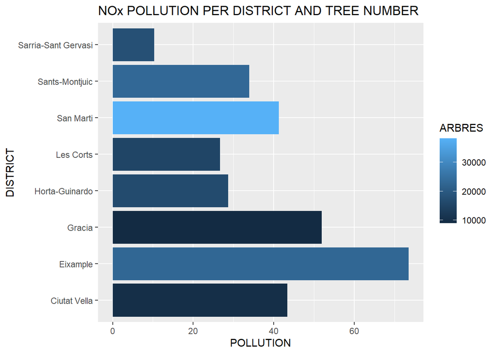

```r
NOx <- filter(air2, CODI_CONTAMINANT == 12)
gNOx <- group_by(NOx, DISTRICTE)
sNOx <- summarise(gNOx, Polucion = mean(Pollution_lvl))
sNOxtree <- left_join(sNOx, strees, by = "DISTRICTE")
sNOxtree[8,3] <- 17951
ggplot(sNOxtree)+
  geom_col(mapping = aes(x = Polucion, y = DISTRICTE, fill = ARBRES))+
  labs(title = "NOx POLLUTION PER DISTRICT AND TREE NUMBER")+
  xlab("POLLUTION")+
  ylab("DISTRICT")
```

In this graph there is exactly the same relationship as in NO2, it is probable that NO2 is the same thing as NOx.

### O3

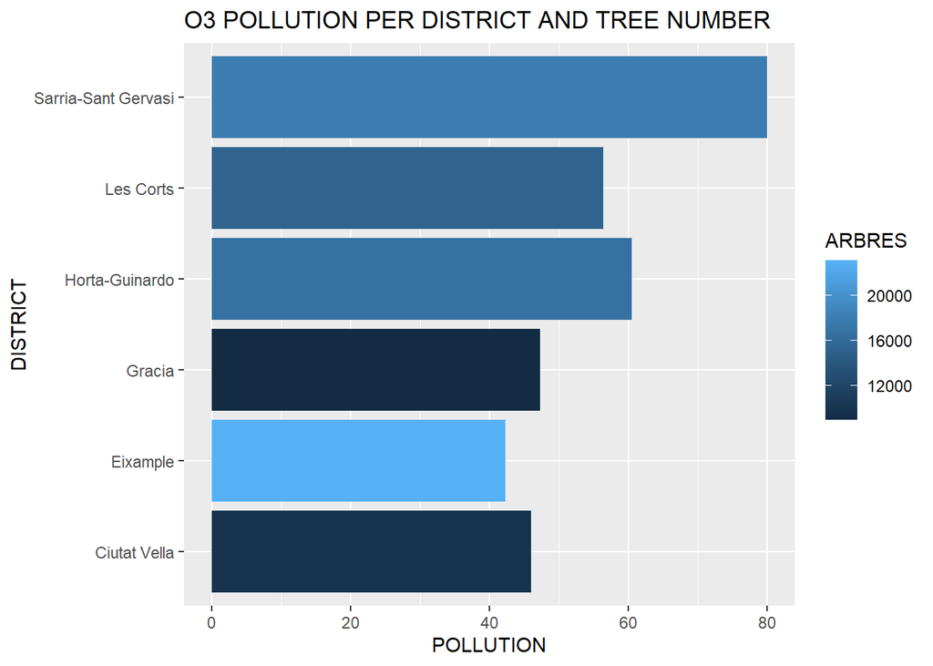

```r
O3 <- filter(air2, CODI_CONTAMINANT == 14)
gO3 <- group_by(O3, DISTRICTE)
sO3 <- summarise(gO3, Polucion = mean(Pollution_lvl))
sO3tree <- left_join(sO3, strees, by = "DISTRICTE")
sO3tree[6,3] <- 17951
ggplot(sO3tree)+
  geom_col(mapping = aes(x = Polucion, y = DISTRICTE, fill = ARBRES))+
  labs(title = "O3 POLLUTION PER DISTRICT AND TREE NUMBER")+
  xlab("POLLUTION")+
  ylab("DISTRICT")
```

### CO

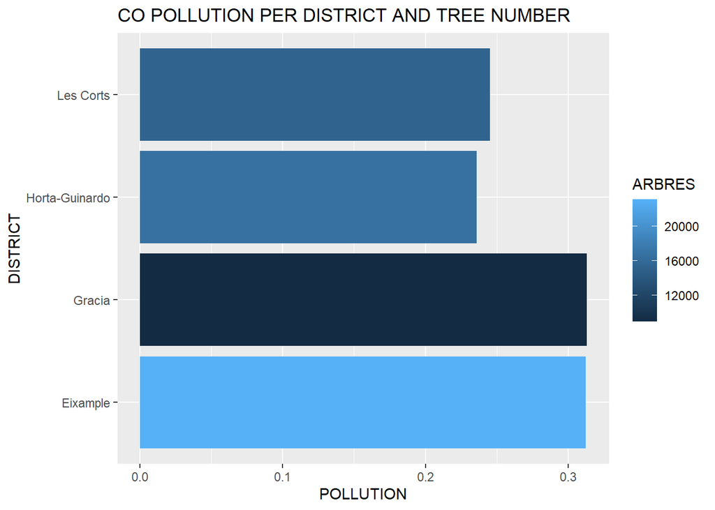

```r
CO <- filter(air2, CODI_CONTAMINANT == 6)
gCO <- group_by(CO, DISTRICTE)
sCO <- summarise(gCO, Polucion = mean(Pollution_lvl))
sCOtree <- left_join(sCO, strees, by = "DISTRICTE")
ggplot(sCOtree)+
  geom_col(mapping = aes(x = Polucion, y = DISTRICTE, fill = ARBRES))+
  labs(title = "CO POLLUTION PER DISTRICT AND TREE NUMBER")+
  xlab("POLLUTION")+
  ylab("DISTRICT")
```

In this graph we can see the relationship between the districts that have the contaminant CO and the pollution levels of each. We can clearly see that there is no relationship between the variables and the amount of trees in each district does not affect the pollution levels of CO.

##PM10

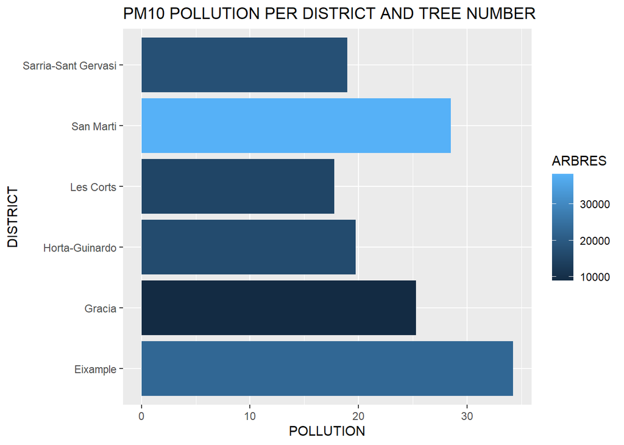

```r
PM10 <- filter(air2, CODI_CONTAMINANT == 10)
gPM10 <- group_by(PM10, DISTRICTE)
sPM10 <- summarise(gPM10, Polucion = mean(Pollution_lvl))
sPM10tree <- left_join(sPM10, strees, by = "DISTRICTE")
sPM10tree[6,3] <- 17951
ggplot(sPM10tree)+
  geom_col(mapping = aes(x = Polucion, y = DISTRICTE, fill = ARBRES))+
  labs(title = "PM10 POLLUTION PER DISTRICT AND TREE NUMBER")+
  xlab("POLLUTION")+
  ylab("DISTRICT")
```

We can see the relationship between the pollution levels of PM10 and the different districts in which this contaminant affects. We also can see the number of trees per district. According to the graph, there is no relationship between the variables and the amount of pollution doesn’t depend on the amount of trees in each district.

### BC

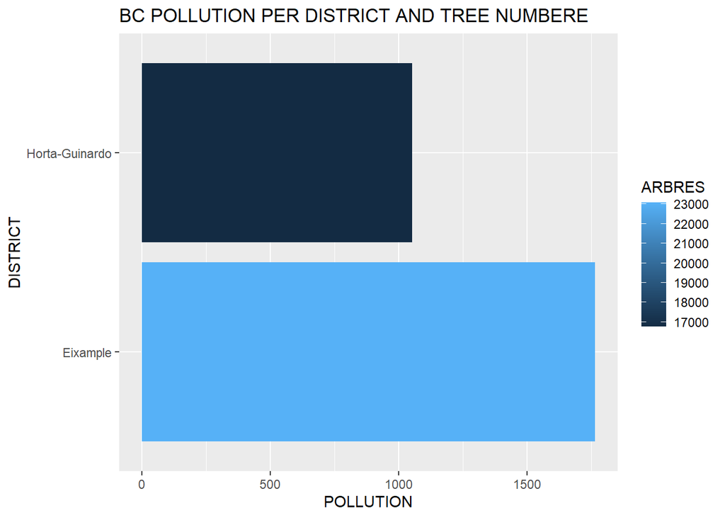

```r
BC <- filter(air2, CODI_CONTAMINANT == 22)
gBC <- group_by(BC, DISTRICTE)
sBC <- summarise(gBC, Polucion = mean(Pollution_lvl))
sBCtree <- left_join(sBC, strees, by = "DISTRICTE")
ggplot(sBCtree)+
  geom_col(mapping = aes(x = Polucion, y = DISTRICTE, fill = ARBRES))+
  labs(title = "BC POLLUTION PER DISTRICT AND TREE NUMBERE")+
  xlab("POLLUTION")+
  ylab("DISTRICT")
```

Here, it only shows the Horta-Guinardo and Eixample areas and their pollution levels according to their number of trees in each area. Another time, the more trees there are in the area, the more polluted it is, which does not really make sense.

### CONCLUSION

**Overall, from all the contaminants, we can barely see any relationship between the pollution levels and the number of trees.This is probably because we are analyzing the number of trees per area and not their density of trees per area. So, the districts that have a higher number of trees are probably bigger and so pollute more.**

## Analyzing the data in a timely manner

### Contaminacio mensual

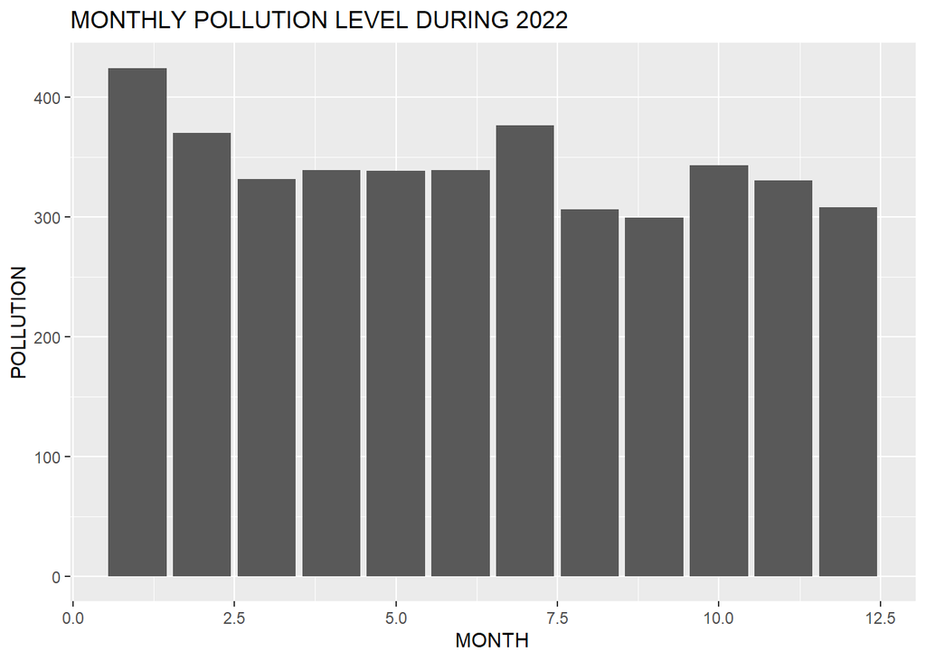

```r
#CONTAMINACION MENSUAL
poljan <- group_by(air2, MES)
poljan2 <- summarise(poljan, Polucion = mean(Pollution_lvl))

ggplot(poljan2)+
  geom_col(mapping = aes(x = MES, y = Polucion))+
  labs(title = "MONTHLY POLLUTION LEVEL DURING 2022")+
  ylab("POLLUTION")+
  xlab("MONTH")
```

In the first months of the year, the pollution levels are higher. The pollution levels of the first two months of the year are higher than the rest, although there is a peak in July. After that increase, the pollution levels decrease again. Overall, all the months represent more or less the same amount of pollution.

### Contaminacio diaria

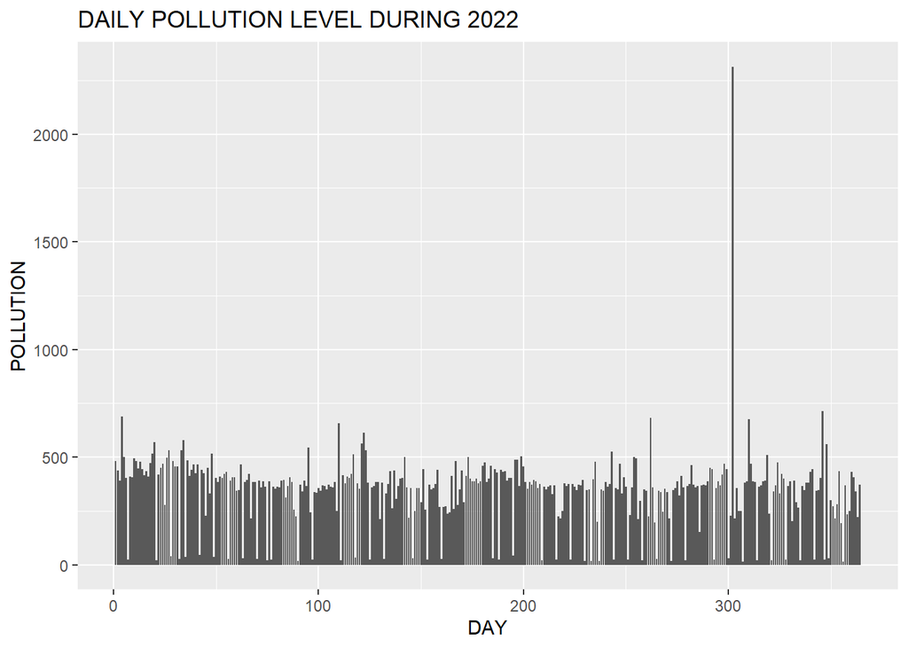

```r
#CONTAMINACION DIARIA
poldia <- group_by(air2, MES, DIA)
poldia2 <- summarise(poldia, Polucion = mean(Pollution_lvl))
poldia2$count <- seq_len(nrow(poldia2))
ggplot(poldia2)+
  geom_col(mapping = aes(x = count, y = Polucion))+
  labs(title = "DAILY POLLUTION LEVEL DURING 2022")+
  xlab("DAY")+
  ylab("POLLUTION")
```

We want to see the day with the highest pollution value for the year 2022

```r
max2022 <- which.max(poldia2$Polucion)
Oct30 <- max(poldia2$Polucion)
```

### Contaminacio por horas

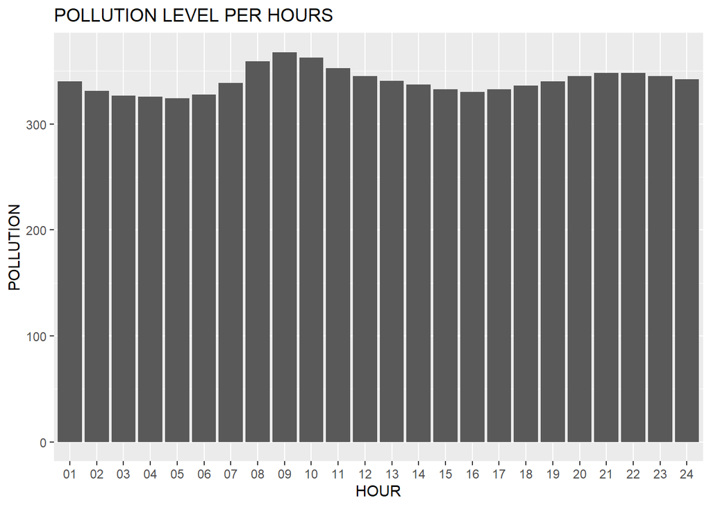

```r
#CONTAMINACION POR HORAS
polhour <- group_by(air2, Hours)
polhour2 <- summarise(polhour, Polucion = mean(Pollution_lvl))
ggplot(polhour2)+
  geom_col(mapping = aes(x = Hours, y = Polucion))+
  labs(title = "POLLUTION LEVEL PER HOURS")+
  xlab("HOUR")+
  ylab("POLLUTION")
```

After analyzing the relationship between pollution levels and hours of the day, we observe that the values increase until 9 am, when it reaches a maximum point, and then decreases over the day until 4 pm, after that time, the pollution levels increase again reaching another maximum at 9 pm, then, the values decrease at night. The high pollution levels are probably due to the entering and exit hours of work/school and the low levels are due to the reduction of traffic.

## Analyzing the polution in each district

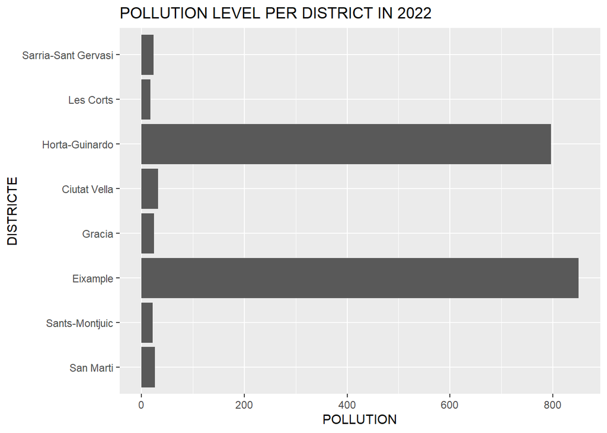

```r
#CONTAMINACION POR DISTRITOS
poldist <- group_by(air2, DISTRICTE)
poldist2 <- summarise(poldist, Polucion = mean(Pollution_lvl))
ggplot(poldist2)+
  geom_col(mapping = aes(x = DISTRICTE, y = Polucion))+
  coord_flip()+
  labs(title = "POLLUTION LEVEL PER DISTRICT IN 2022")+
  ylab("POLLUTION")
```

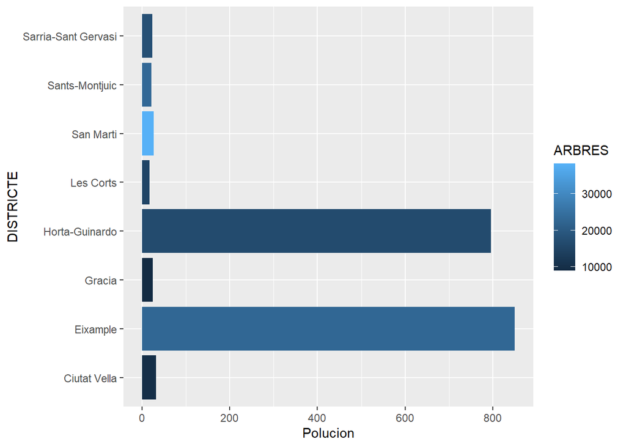

```r
#CONTAMINACION Y ARBOLES POR DISTRITO
names(strees) <- c("DISTRICTE", "ARBRES")

poltrees <- left_join(poldist2, strees, by = "DISTRICTE")
poltrees[8,3] <- 17951

ggplot(poltrees)+
  geom_col(mapping = aes(y = DISTRICTE, x = Polucion, fill = ARBRES))
```

As we saw in the graph above, Horta - Guinardo and Eixample are the two districts with the highest levels of pollution even though they are not the areas with the least amount of trees, meaning that the green level does not affect at all the level of pollution per district.

# CREATING A NEW DATASET WITH THE SIZE AND POPULATION IN EACH DISTRICT

We took the information from wikipedia and created the new dataset with vectors

```r
#NUEVO DATASET CON LA DENSIDAD POR DISTRITO
DISTRICTE <- c("Ciutat Vella", "Eixample", "Sants-Montjuic", "Les Corts",
               "Sarria-Sant Gervasi", "Gracia", "Horta-Guinardo", "San Marti")
KM <- c(4.11, 7.46, 22.68, 6.02, 19.91, 4.19, 11.96, 10.39)
POBLACIO <- c(109672, 269349, 187026, 81576, 149201, 123276, 173944, 241181)

gente <- data.frame(DISTRICTE = DISTRICTE, KM2 = KM, POBLACIO = POBLACIO)
```

We do a left join with the dataset just created before and poltrees by the variable DISTRICT. Afterwards, we mutate the new dataset creating two new variables, DENSITAT and GREEN_LEVEL.

```r
#RELACION ENTRE DENSIDAD Y POLUCION
polden <- left_join(poltrees, gente, by = "DISTRICTE")
polden2 <- mutate(polden, DENSITAT = POBLACIO/KM2)
polden2 <- mutate(polden2, GREEN_LEVEL = ARBRES/KM2)
```

## Analyzing the Green level per each district

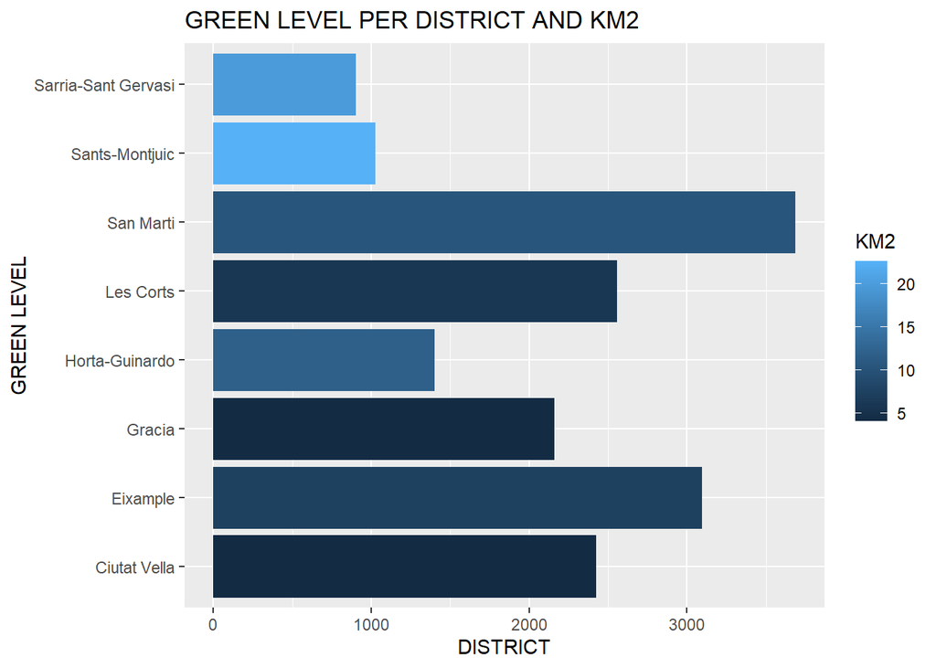

```r
#GREEN LEVEL POR DISTRITO
glvl <- group_by(polden2, DISTRICTE)
slvl <- summarise(glvl, GREEN_LEVEL, KM2)
ggplot(slvl)+
  geom_col(mapping = aes(x = DISTRICTE, y = GREEN_LEVEL, fill = KM2))+
  coord_flip()+
  labs(title = "GREEN LEVEL PER DISTRICT AND KM2")+
  xlab("GREEN LEVEL")+
  ylab("DISTRICT")
```

## Analyzing each contaminant in a timely manner and in relation with the Green level

### *CONTAMINANT SO2*

### Mensual pollution of SO2

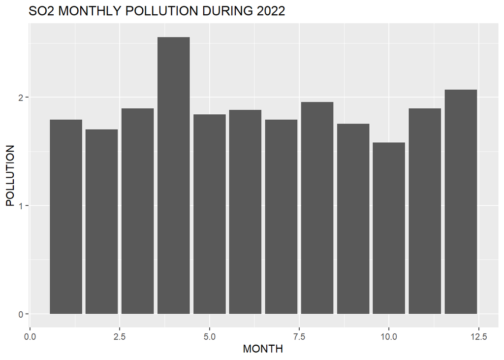

```r
#SO2 POR MES Y DIA
SO2mes <- group_by(SO2, MES)
sSO2mes <- summarise(SO2mes, POLUCIO = mean(Pollution_lvl))
ggplot(sSO2mes)+
  geom_col(mapping = aes(x = MES, y = POLUCIO))+
  labs(title = "SO2 MONTHLY POLLUTION DURING 2022")+
  xlab("MONTH")+
  ylab("POLLUTION")
```

The relationship between the months of the year and the pollution levels of SO2. In the first graph, April stands out as the most polluted one but all the rest have more or less the same pollution levels.

### Daily pollution of SO2

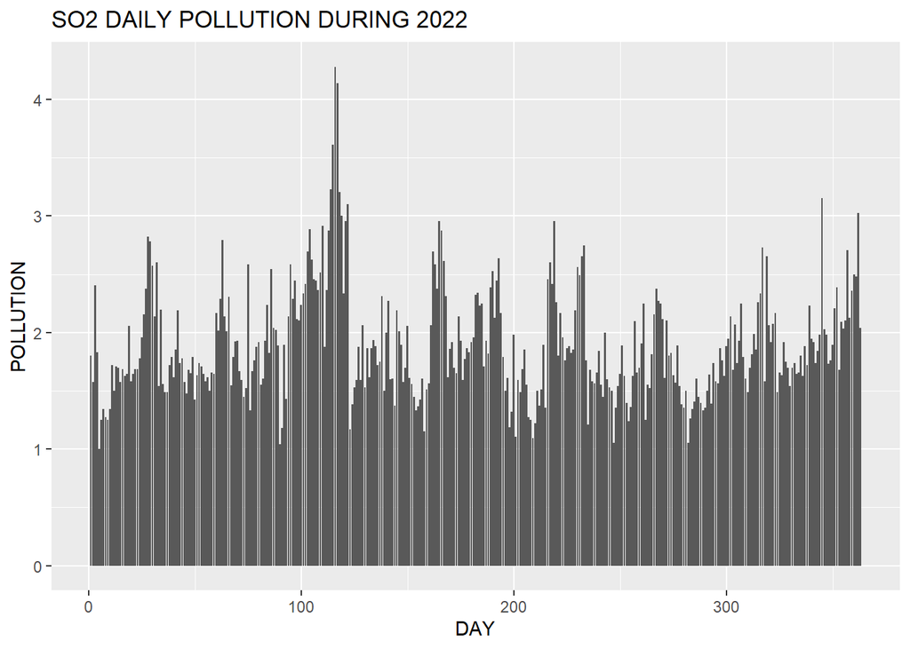

```r
SO2dia <- group_by(SO2, MES, DIA)
sSO2dia <- summarise(SO2dia, POLUCIO = mean(Pollution_lvl))
sSO2dia$count <- seq_len(nrow(sSO2dia))
ggplot(sSO2dia)+
  geom_col(mapping = aes(x = count, y = POLUCIO))+
  labs(title = "SO2 DAILY POLLUTION DURING 2022")+
  xlab("DAY")+
  ylab("POLLUTION")
```

```r
maxSO2 <- which.max(sSO2dia$POLUCIO)
Apr27 <- max(sSO2dia$POLUCIO)
```

With its relation per day, there are multiple peaks one of which is higher than the others, on April 27.

### Pollution in each district of SO2 related with the green level

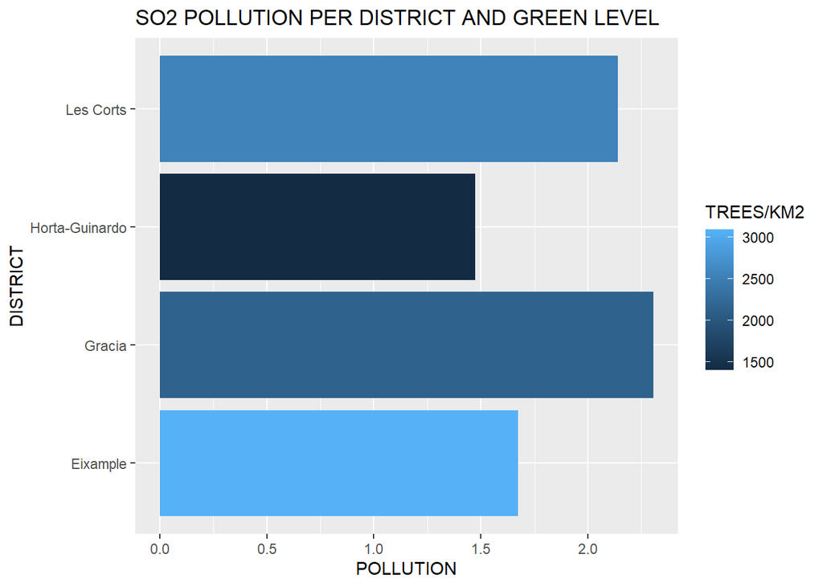

```r
SO2slvl <- left_join(SO2tree, slvl, by = "DISTRICTE")
ggplot(SO2slvl)+
  geom_col(mapping = aes(x = Polucion, y = DISTRICTE, fill = GREEN_LEVEL))+
  labs(title = "SO2 POLLUTION PER DISTRICT AND GREEN LEVEL", fill = "TREES/KM2")+
  xlab("POLLUTION")+
  ylab("DISTRICT")
```

In the next graph, the relationship between the level of pollution of SO2 and the green level (density of trees) of each of the districts. We can see that Eixample is the district with more trees per Km2, however it is not the least polluted of SO2, this one is Horta - Guinardó. The most polluted one is Gràcia.

### *CONTAMINANT NO*

### Monthly pollution of NO

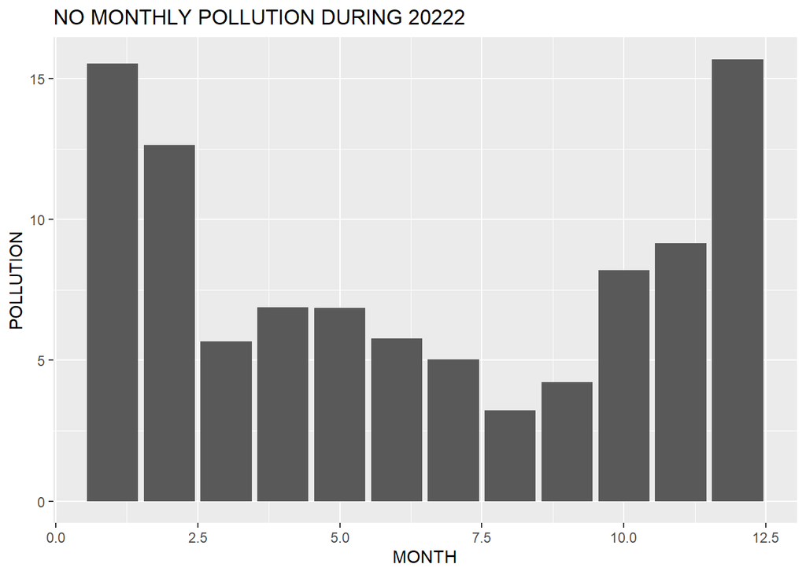

```r
#NO POR MES Y DIA
NOmes <- group_by(NO, MES)
sNOmes <- summarise(NOmes, POLUCIO = mean(Pollution_lvl))
ggplot(sNOmes)+
  geom_col(mapping = aes(x = MES, y = POLUCIO))+
  labs(title = "NO MONTHLY POLLUTION DURING 20222")+
  xlab("MONTH")+
  ylab("POLLUTION")
```

### Daily pollution of NO

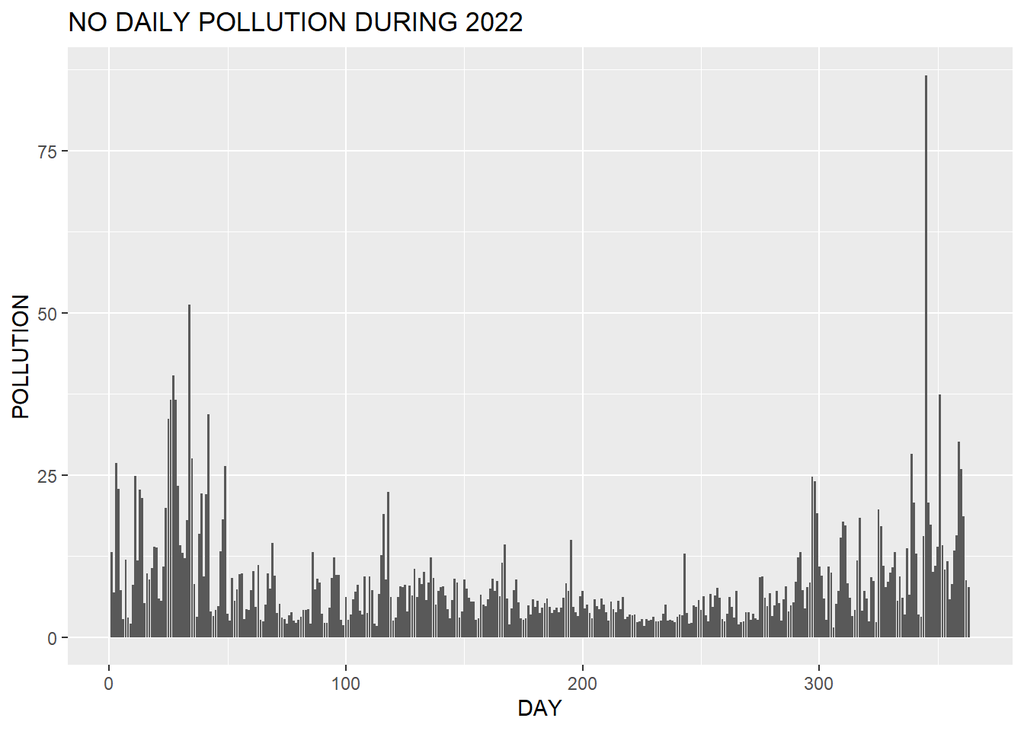

```r
NOdia <- group_by(NO, MES, DIA)
sNOdia <- summarise(NOdia, POLUCIO = mean(Pollution_lvl))
sNOdia$count <- seq_len(nrow(sNOdia))
ggplot(sNOdia)+
  geom_col(mapping = aes(x = count, y = POLUCIO))+
  labs(title = "NO DAILY POLLUTION DURING 2022", fill = "TREES/KM2")+
  xlab("DAY")+
  ylab("POLLUTION")
```

```r
maxNO <- which.max(sNOdia$POLUCIO)
Dec13 <- max(sNOdia$POLUCIO)
```

In this graph we compare the pollution level of NO per day of the year. We see that there is an outlier at the end of the year, with a value reaching very high levels. We confirm the monthly graph we saw above, how the first part of the year the pollution levels are very high and so are the last ones, but there is a diminution during the year.

### Pollution in each district of NO related with the green level

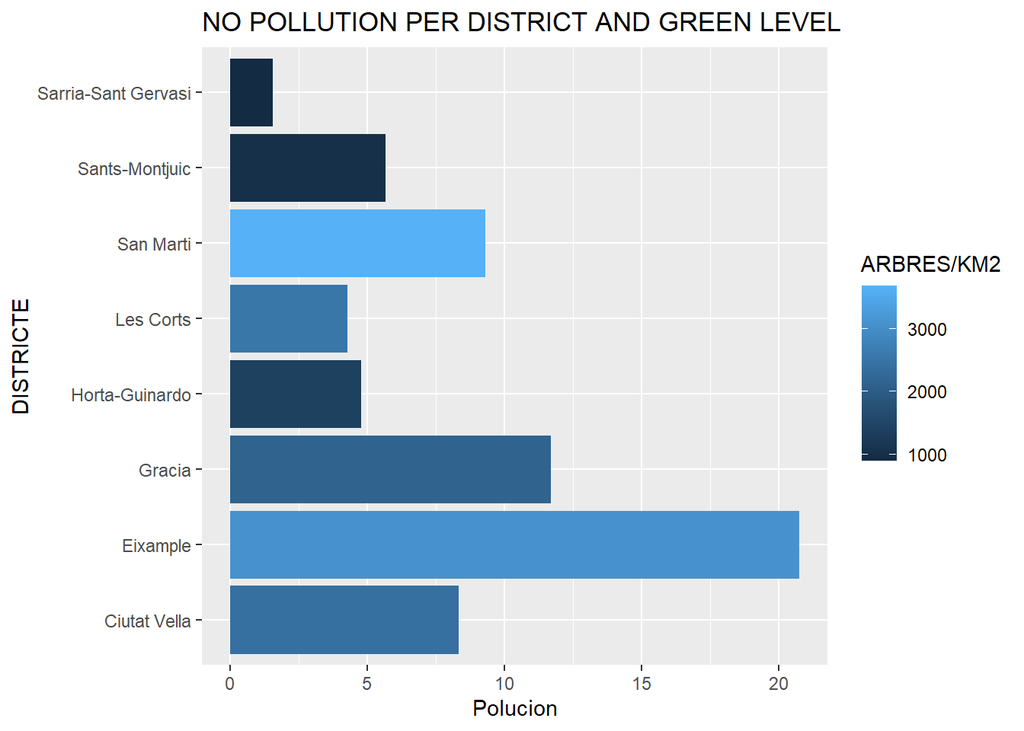

```r
NOlvl <- left_join(sNOtree, slvl, by = "DISTRICTE")
ggplot(NOlvl)+
  geom_col(mapping = aes(x = Polucion, y = DISTRICTE, fill = GREEN_LEVEL))+
  labs(title = "NO POLLUTION PER DISTRICT AND GREEN LEVEL", fill = "ARBRES/KM2")
```

In this case, another time the pollution levels of NO of each district are compared to the density of trees of the area. There is barely any relationship as Eixample is one of the most densified areas in terms of trees but is the highest one in terms of pollution.

### *CONTAMINANT NO2*

### Monthly pollution of NO2

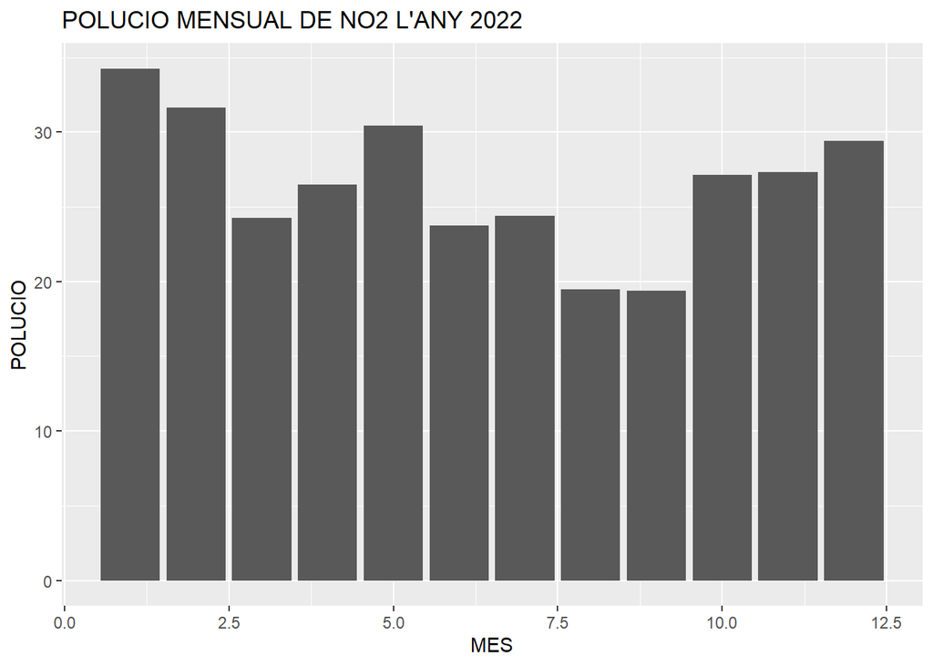

```r
#NO2 POR MES Y DIA
NO2mes <- group_by(NO2, MES)
sNO2mes <- summarise(NO2mes, POLUCIO = mean(Pollution_lvl))
ggplot(sNO2mes)+
  geom_col(mapping = aes(x = MES, y = POLUCIO))+
  labs(title = "POLUCIO MENSUAL DE NO2 L'ANY 2022")
```

In this graph we can see the relationship between the pollution levels of NO2 and the different months of the year. All the values are high, meaning that there is a lot of pollution of this contaminant during the whole year. The maximum level it reaches is in January and the smallest during summer time.

### Daily pollution of NO2

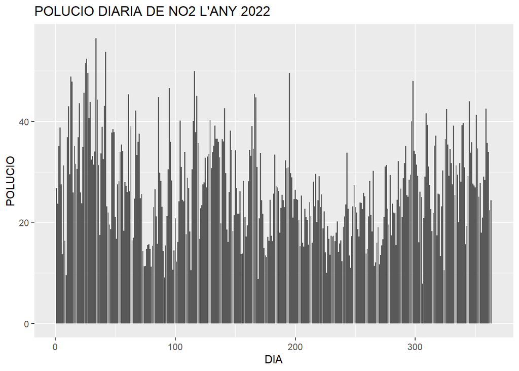

```r
NO2dia <- group_by(NO2, MES, DIA)
sNO2dia <- summarise(NO2dia, POLUCIO = mean(Pollution_lvl))
sNO2dia$count <- seq_len(nrow(sNO2dia))
ggplot(sNO2dia)+
  geom_col(mapping = aes(x = count, y = POLUCIO))+
  labs(title = "POLUCIO DIARIA DE NO2 L'ANY 2022")+
  xlab("DIA")
```

```r
maxNO2 <- which.max(sNO2dia$POLUCIO)
Feb3 <- max(sNO2dia$POLUCIO)
```

### Pollution in each district of NO2 related with the green level

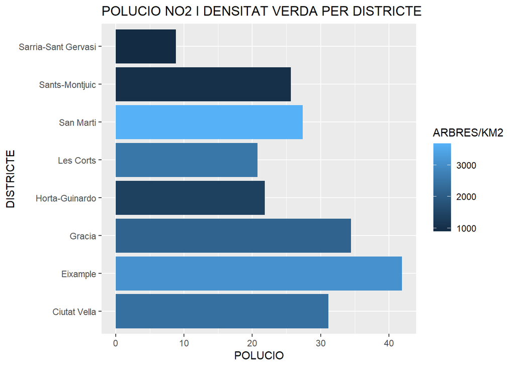

```r
NO2lvl <- left_join(sNO2tree, slvl, by = "DISTRICTE")
ggplot(NO2lvl)+
  geom_col(mapping = aes(x = Polucion, y = DISTRICTE, fill = GREEN_LEVEL))+
  labs(title = "POLUCIO NO2 I DENSITAT VERDA PER DISTRICTE", fill = "ARBRES/KM2")+
  xlab("POLUCIO")
```

Here we are evaluating the pollution levels of NO2 per district and the trees per km2. We can see that Eixample is the most polluted district but not the one that has the most km2 of trees. The least polluted one is Sarrià - Sant Gervasi and it’s the one that has less trees per km2. This means that there is no relationship between the amount of trees per km2 and the pollution levels of that district.

### *CONTAMINANT PM2.5*

### Monthly pollution of PM2.5

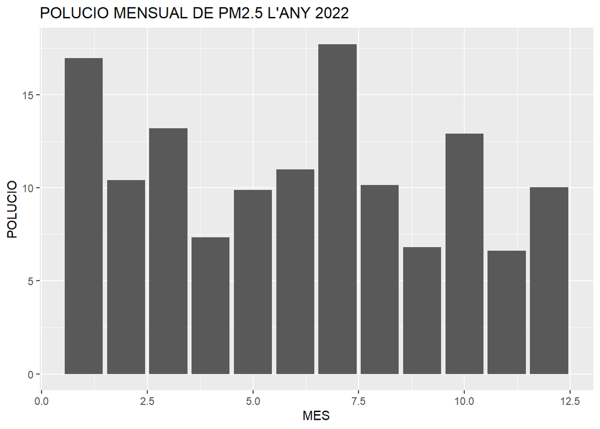

```r
#PM2.5 POR MES Y DIA
PM2.5mes <- group_by(PM2.5, MES)
sPM2.5mes <- summarise(PM2.5mes, POLUCIO = mean(Pollution_lvl))
ggplot(sPM2.5mes)+
  geom_col(mapping = aes(x = MES, y = POLUCIO))+
  labs(title = "POLUCIO MENSUAL DE PM2.5 L'ANY 2022")
```

In this graph we can see the relationship between the pollution levels of PM2.5 and the different months of the year. There are two peaks in January and in July, which means that those months have had high levels of PM2.5.

### Daily pollution of PM2.5

```r
PM2.5dia <- group_by(PM2.5, MES, DIA)
sPM2.5dia <- summarise(PM2.5dia, POLUCIO = mean(Pollution_lvl))
```

[output not shown]

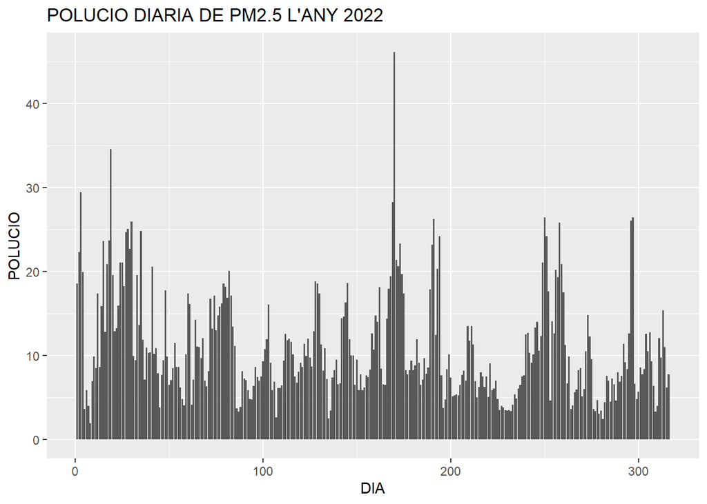

```r
sPM2.5dia$count <- seq_len(nrow(sPM2.5dia))
ggplot(sPM2.5dia)+
  geom_col(mapping = aes(x = count, y = POLUCIO))+
  labs(title = "POLUCIO DIARIA DE PM2.5 L'ANY 2022")+
  xlab("DIA")
```

```r
maxPM2.5 <- which.max(sPM2.5dia$POLUCIO)
Jul24 <- max(sPM2.5dia$POLUCIO)
```

In this graph we see the relationship between the pollution levels of PM2.5 and all the days of the year. We observe that there is a peak on July 24 but overall there isn’t a clear relationship. We can tell that at the beginning of the year and in the summer the pollution levels of PM2.5 are high.

### Pollution in each district of PM2.5 related with the green level

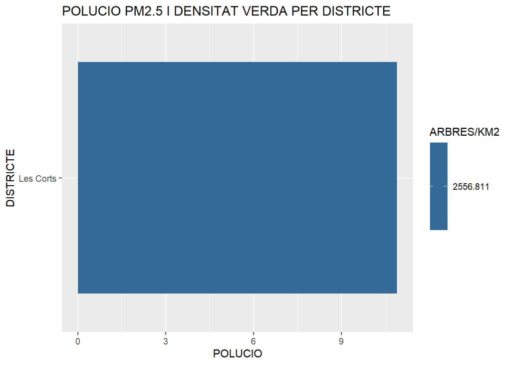

```r
PM2.5lvl <- left_join(sPM2.5tree, slvl, by = "DISTRICTE")
ggplot(PM2.5lvl)+
  geom_col(mapping = aes(x = Polucion, y = DISTRICTE, fill = GREEN_LEVEL))+
  labs(title = "POLUCIO PM2.5 I DENSITAT VERDA PER DISTRICTE", fill = "ARBRES/KM2")+
  xlab("POLUCIO")
```

As only Les Corts are being analysed, we cannot take any conclusions of this graph.

### *CONTAMINANT NOx*

### Monthly pollution of NOx

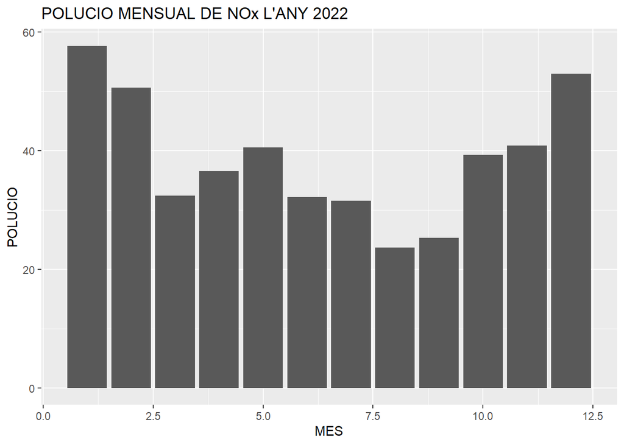

```r
#NOx POR MES Y DIA
NOxmes <- group_by(NOx, MES)
sNOxmes <- summarise(NOxmes, POLUCIO = mean(Pollution_lvl))
ggplot(sNOxmes)+
  geom_col(mapping = aes(x = MES, y = POLUCIO))+
  labs(title = "POLUCIO MENSUAL DE NOx L'ANY 2022")
```

In this graph where the relationship between the months of the year and the pollution levels of NOx are presented, we can observe that in the first and last months of the year, the pollution of NOx is higher.

### Daily pollution of NOx

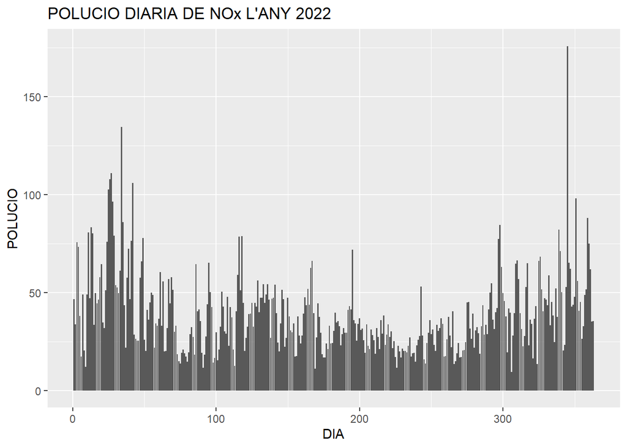

```r
NOxdia <- group_by(NOx, MES, DIA)
sNOxdia <- summarise(NOxdia, POLUCIO = mean(Pollution_lvl))
sNOxdia$count <- seq_len(nrow(sNOxdia))
ggplot(sNOxdia)+
  geom_col(mapping = aes(x = count, y = POLUCIO))+
  labs(title = "POLUCIO DIARIA DE NOx L'ANY 2022")+
  xlab("DIA")
```

```r
maxNOx <- which.max(sNOxdia$POLUCIO)
Dec13NOx <- max(sNOxdia$POLUCIO)
```

The pollution of NOx is represented each day of the year. There is clearly a peak at the end of the year, on December 13.

### Pollution in each district of NOx related with the green level

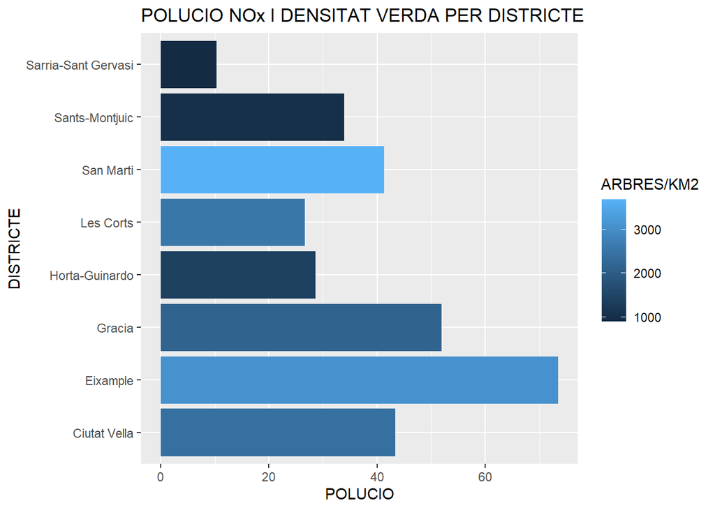

```r
NOxlvl <- left_join(sNOxtree, slvl, by = "DISTRICTE")
ggplot(NOxlvl)+
  geom_col(mapping = aes(x = Polucion, y = DISTRICTE, fill = GREEN_LEVEL))+
  labs(title = "POLUCIO NOx I DENSITAT VERDA PER DISTRICTE", fill = "ARBRES/KM2")+
  xlab("POLUCIO")
```

In this graph we observe the comparison between the pollution levels of each district of NOx and the trees per Km2. Eixample is the most polluted district and Sarrià - Sant Gervasi the least. San Martí is the district with the highest number of trees per km2 and Sarrià - Sant Gervasi the one with less.

### *CONTAMINANT O3*

### Monthly pollution of 03

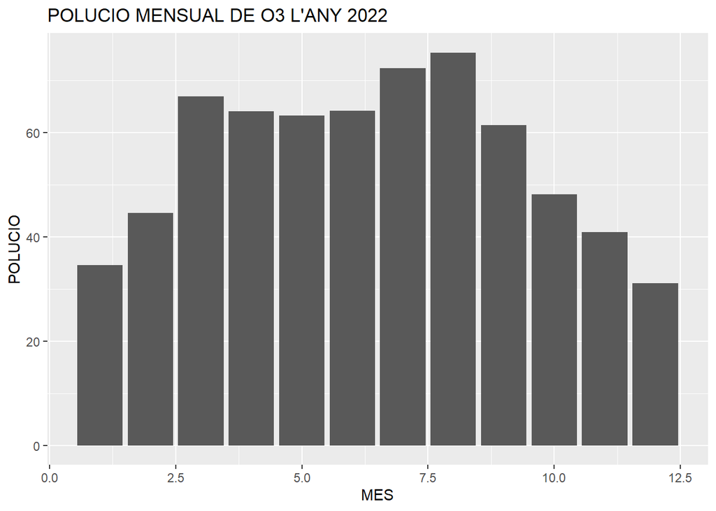

```r
#O3 POR MES Y DIA
O3mes <- group_by(O3, MES)
sO3mes <- summarise(O3mes, POLUCIO = mean(Pollution_lvl))
ggplot(sO3mes)+
  geom_col(mapping = aes(x = MES, y = POLUCIO))+
  labs(title = "POLUCIO MENSUAL DE O3 L'ANY 2022")
```

The relationship between the months of the year and the pollution levels of O3 is shown. From March to August, the pollution of O3 is higher.

### Daily pollution of O3

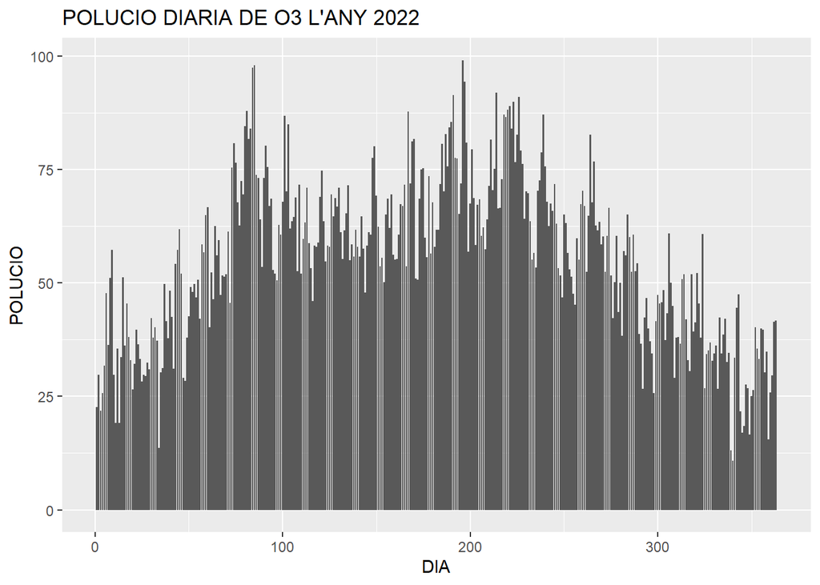

```r
O3dia <- group_by(O3, MES, DIA)
sO3dia <- summarise(O3dia, POLUCIO = mean(Pollution_lvl))
sO3dia$count <- seq_len(nrow(sO3dia))
ggplot(sO3dia)+
  geom_col(mapping = aes(x = count, y = POLUCIO))+
  labs(title = "POLUCIO DIARIA DE O3 L'ANY 2022")+
  xlab("DIA")
```

```r
maxO3 <- which.max(sO3dia$POLUCIO)
Jul16 <- max(sO3dia$POLUCIO)
```

In this graph we compare the pollution level of O3 per day. We observe how the values increase since January 1, reaching a max on July 16. Then they decrease again. Overall we can say that the pollution levels of O3 are very high especially in the summer.

### Pollution in each district of 03 related with the green level

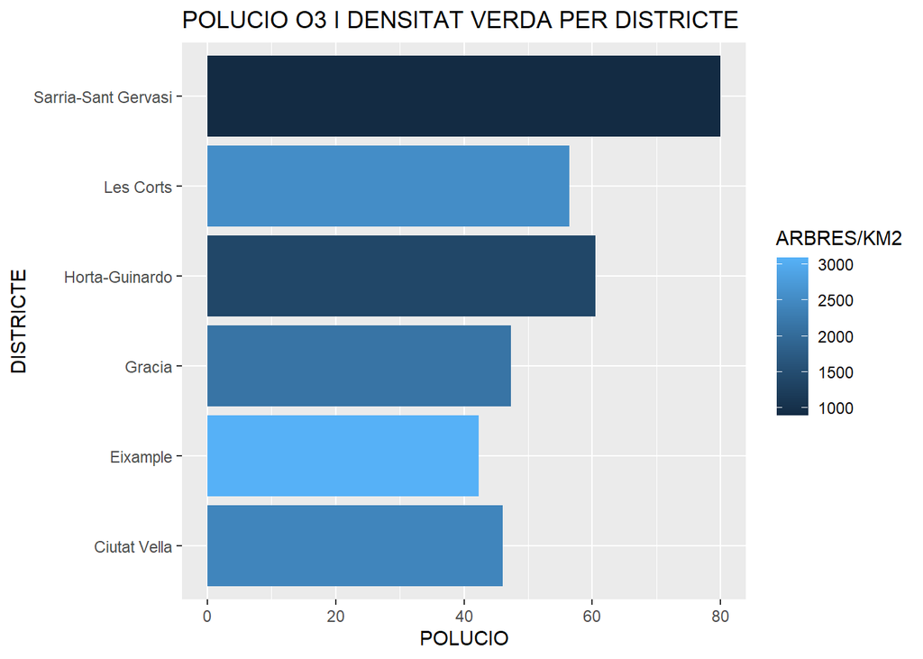

```r
sO3lvl <- left_join(sO3tree, slvl, by = "DISTRICTE")
ggplot(sO3lvl)+
  geom_col(mapping = aes(x = Polucion, y = DISTRICTE, fill = GREEN_LEVEL))+
  labs(title = "POLUCIO O3 I DENSITAT VERDA PER DISTRICTE", fill = "ARBRES/KM2")+
  xlab("POLUCIO")
```

In this case, in this graph there is a little relationship between the pollution levels of O3 in each neighborhood and the tree density in each area. Here, there is a little relationship with the pollution and the green level. The more density of trees there is in the area, the less contaminated and viceversa. For example, Sarria-Sant Gervasi is the more polluted and the less dense of trees there are. Then, Eixample is the less polluted and the more dense of trees it is.

### *CONTAMINANT CO*

### Monthly pollution CO

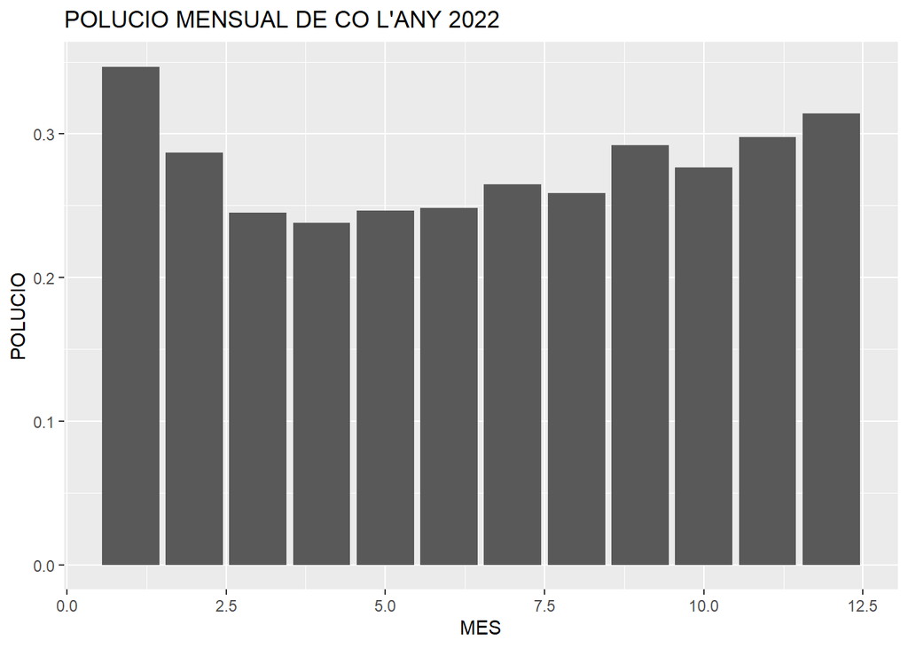

```r
#CO POR MES Y DIA
COmes <- group_by(CO, MES)
sCOmes <- summarise(COmes, POLUCIO = mean(Pollution_lvl))
ggplot(sCOmes)+
  geom_col(mapping = aes(x = MES, y = POLUCIO))+
  labs(title = "POLUCIO MENSUAL DE CO L'ANY 2022")
```

### Daily pollution of CO

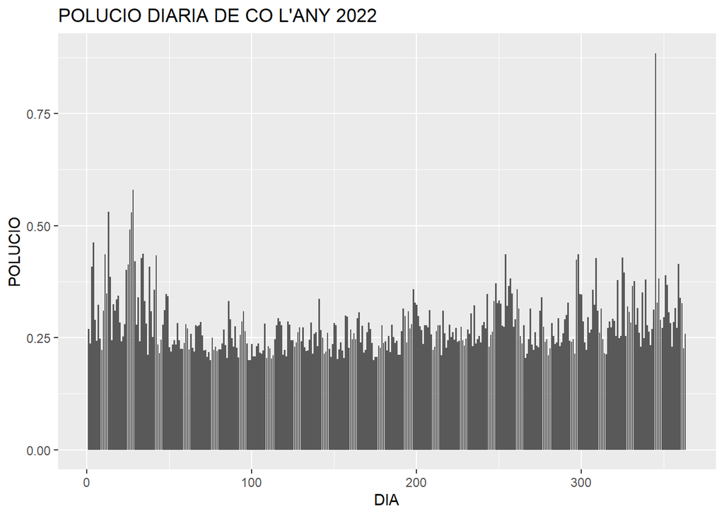

```r
COdia <- group_by(CO, MES, DIA)
sCOdia <- summarise(COdia, POLUCIO = mean(Pollution_lvl))
sCOdia$count <- seq_len(nrow(sCOdia))
ggplot(sCOdia)+
  geom_col(mapping = aes(x = count, y = POLUCIO))+
  labs(title = "POLUCIO DIARIA DE CO L'ANY 2022")+
  xlab("DIA")
```

```r
maxCO <- which.max(sCOdia$POLUCIO)
Dec13CO <- max(sCOdia$POLUCIO)
```

Here we compare the levels of pollution of CO and the days of the year. We see that the first days of the year the contamination starts growing but then it stabilizes at a level of 0.25 until the end of the year when there is an outlier. This observation reaches a maximum of over 0.75 levels of pollution and it happens on December 13.

### Pollution in each district of CO related with the green level

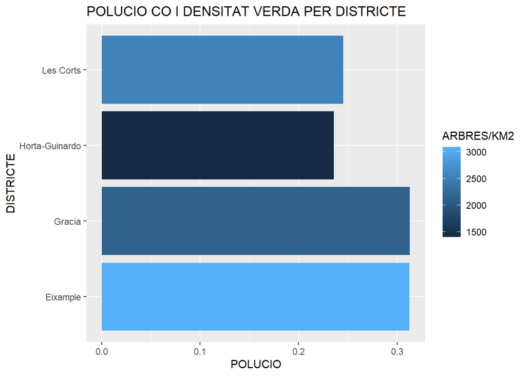

```r
COlvl <- left_join(sCOtree, slvl, by = "DISTRICTE")
ggplot(COlvl)+
  geom_col(mapping = aes(x = Polucion, y = DISTRICTE, fill = GREEN_LEVEL))+
  labs(title = "POLUCIO CO I DENSITAT VERDA PER DISTRICTE", fill = "ARBRES/KM2")+
  xlab("POLUCIO")
```

The relation between the pollution levels of CO and the density of trees per area is shown in the graph. Eixample is the most polluted one in terms of CO and has the highest density of trees. Whereas, Horta-Guinardó is less polluted and has less density of trees.

### *CONTAMINANT PM10*

### Monthly pollution of PM10

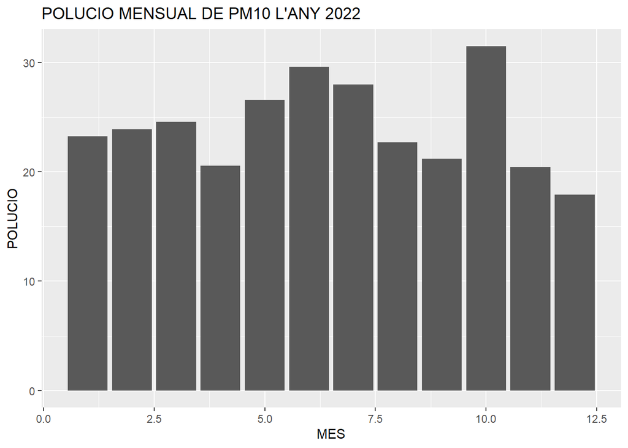

```r
#PM10 POR MES Y DIA
PM10mes <- group_by(PM10, MES)
sPM10mes <- summarise(PM10mes, POLUCIO = mean(Pollution_lvl))
ggplot(sPM10mes)+
  geom_col(mapping = aes(x = MES, y = POLUCIO))+
  labs(title = "POLUCIO MENSUAL DE PM10 L'ANY 2022")
```

October is the most polluted month in terms of PM10 and from May to June there is also a peak. The other months are more or less the same in terms of their pollution of PM10.

### Daily pollution of PM10

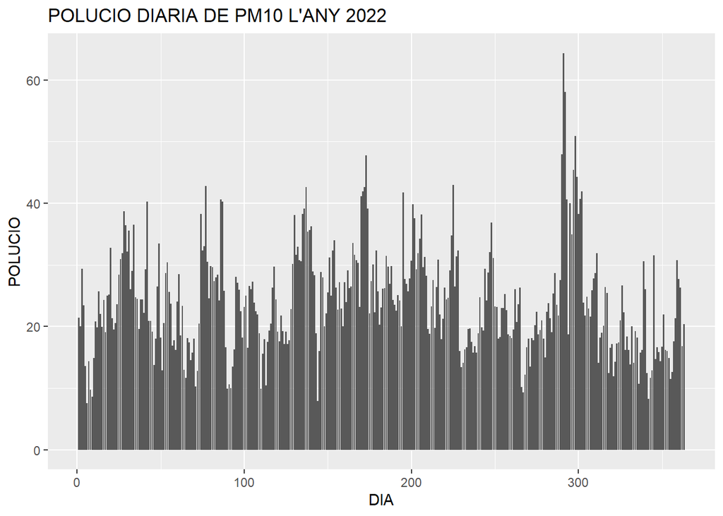

```r
PM10dia <- group_by(PM10, MES, DIA)
sPM10dia <- summarise(PM10dia, POLUCIO = mean(Pollution_lvl))
sPM10dia$count <- seq_len(nrow(sPM10dia))
ggplot(sPM10dia)+
  geom_col(mapping = aes(x = count, y = POLUCIO))+
  labs(title = "POLUCIO DIARIA DE PM10 L'ANY 2022")+
  xlab("DIA")
```

```r
maxPM10 <- which.max(sPM10dia$POLUCIO)
Oct19 <- max(sPM10dia$POLUCIO)
```

This graph compares the pollution levels of PM10 and the different days of the year. We can see how the levels of pollution increase and decrease without a relationship, reaching a maximum point at the end of the year, on October 19.

### Pollution in each district of PM10 related with the green level

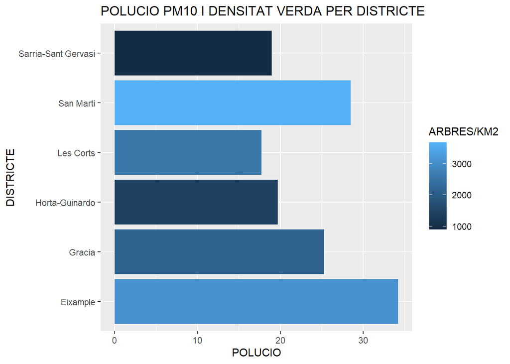

```r
PM10lvl <- left_join(sPM10tree, slvl, by = "DISTRICTE")
ggplot(PM10lvl)+
  geom_col(mapping = aes(x = Polucion, y = DISTRICTE, fill = GREEN_LEVEL))+
  labs(title = "POLUCIO PM10 I DENSITAT VERDA PER DISTRICTE", fill = "ARBRES/KM2")+
  xlab("POLUCIO")
```

### *CONTAMINANT BC*

### Montly pollution of BC

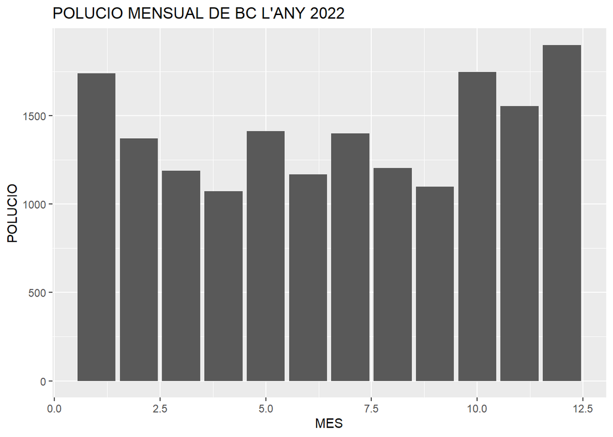

```r
#BC POR MES Y DIA
BCmes <- group_by(BC, MES)
sBCmes <- summarise(BCmes, POLUCIO = mean(Pollution_lvl))
ggplot(sBCmes)+
  geom_col(mapping = aes(x = MES, y = POLUCIO))+
  labs(title = "POLUCIO MENSUAL DE BC L'ANY 2022")
```

### Daily pollution of BC

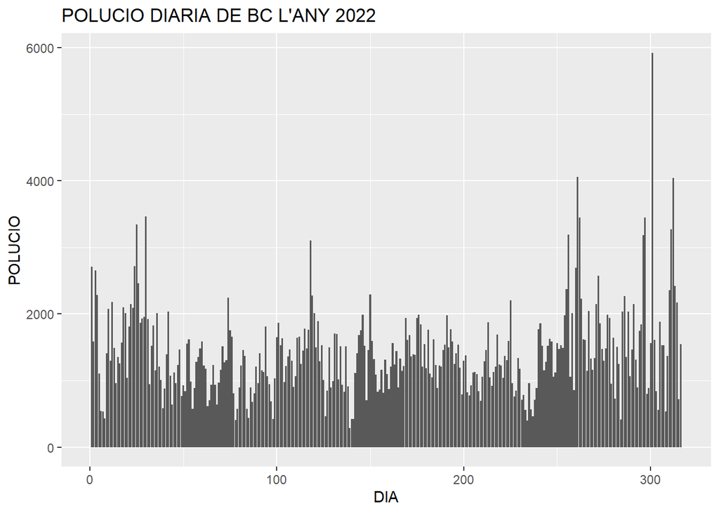

```r
BCdia <- group_by(BC, MES, DIA)
sBCdia <- summarise(BCdia, POLUCIO = mean(Pollution_lvl))
sBCdia$count <- seq_len(nrow(sBCdia))
ggplot(sBCdia)+
  geom_col(mapping = aes(x = count, y = POLUCIO))+
  labs(title = "POLUCIO DIARIA DE BC L'ANY 2022")+
  xlab("DIA")
```

```r
maxBC <- which.max(sBCdia$POLUCIO)
Dec13BC <- max(sBCdia$POLUCIO)
```

The comparison of the pollution levels of BC and the days of the year shows us that the pollution levels over the year are more or less stable whereas there is a peak of BC in the day December 13 another time.

### Pollution in each district of BC related with the green level

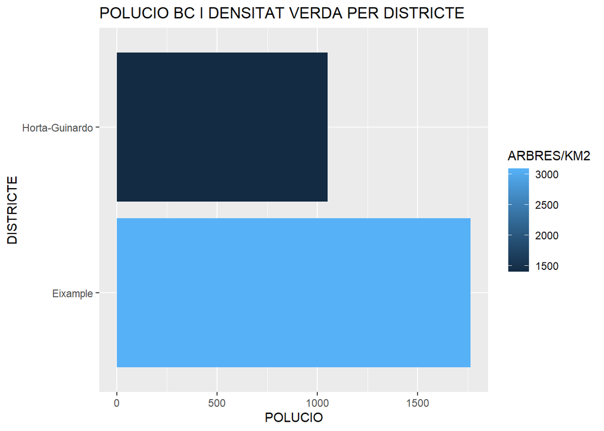

```r
BClvl <- left_join(sBCtree, slvl, by = "DISTRICTE")
ggplot(BClvl)+
  geom_col(mapping = aes(x = Polucion, y = DISTRICTE, fill = GREEN_LEVEL))+
  labs(title = "POLUCIO BC I DENSITAT VERDA PER DISTRICTE", fill = "ARBRES/KM2")+
  xlab("POLUCIO")
```

This contaminant is only captured in Horta - Guinardó and Eixample. This last one represents a higher value of pollution than Horta but at the same time a higher number of trees per Km2.

**How are the pollution indexes evolving during the year? Is there any particular peak in any month, day or hour of the day that you consider concerning?**

**Which is the impact of the “green level” (density of trees) in these indicators? Are the trees helping keep the air clean at all?**

**Which neighborhoods are more and which are less polluted? Which is the amount of population involved in the best (and worse) neighborhoods?**